# Guest Lecture: MCMC — Gibbs Sampling & Metropolis–Hastings

Code, Packages & Diagnostics

Justin Kao

# 🧰 Course Tools

## Markdown & Quarto: Your Storytelling Superpowers

- 🧠 **R Markdown or Quarto:** Make sure it *knits*, *renders*, and *saves* without RStudio crying.  
  (If it knits, you’re officially a data scientist.)
- 📝 [**Markdown Basics**](https://quarto.org/docs/authoring/markdown-basics.html) — Learn how to make text bold, italic, draw diagrams, or show off anything you want to demonstrate.
- 🚀 [**Hello, Quarto**](https://quarto.org/docs/get-started/hello/rstudio.html) by Dr. Mine Çetinkaya-Rundel (Duke University) — From *“What’s a chunk?”* to *“Look, I just published my work on GitHub!”*

# Markov Chain Monte Carlo(MCMC)

## MCMC - Gibbs sampler: the problem

So far, we have covered conjugate and semi-conjugate posteriors — these gave us nice closed forms. But what if the joint posterior looks something like this?

$$p(\boldsymbol{\theta} \mid \mathbf{x}) \propto \left(\prod_{i=1}^n \frac{1}{\sqrt{2\pi}\sigma} e^{-\frac{(x_i - \mu)^2}{2\sigma^2}}\right) \cdot \frac{1}{\sigma^{2(\alpha+1)}} e^{-\beta/\sigma^2} \cdot \frac{1}{\sqrt{2\pi}\tau} e^{-\frac{(\mu-m)^2}{2\tau^2}} \cdot \frac{\lambda^{a-1} e^{-b\lambda}}{1 + e^{-\gamma(\mu - \lambda\bar{x})}}$$

**Direct sampling is hard** — the joint posterior can live in high dimensions with no tractable form.

**Key insight:** even though the joint $p(\boldsymbol{\theta} \mid \mathbf{x})$ is hard to sample from directly, if we can derive each parameter’s *full conditional* distribution — conditioning on all other parameters — those are often much simpler:

$$p(\theta_j \mid \theta_1, \ldots, \theta_{j-1}, \theta_{j+1}, \ldots, \theta_p, \mathbf{x}) \quad \text{for each } j = 1, \ldots, p$$

These full conditionals are just slices of the joint — and slices of a nasty joint are often recognizable distributions we know how to sample from.

So instead of tackling the full joint at once, we sample one parameter at a time — treating all others as fixed constants. Each step is a simple **univariate** draw.

## MCMC - Gibbs sampler: the idea

Start with some initial guess $(\theta_1^{(1)}, \theta_2^{(1)})$. Then for $t = 2, 3, \ldots$:

**Step 1.** Sample $\theta_1^{(t)}$ from $p(\theta_1 \mid \theta_2^{(t-1)}, \mathbf{x})$ — treat $\theta_2$ as **fixed**, sample $\theta_1$

**Step 2.** Sample $\theta_2^{(t)}$ from $p(\theta_2 \mid \theta_1^{(t)}, \mathbf{x})$ — treat the **new** $\theta_1$ as fixed, sample $\theta_2$

Each draw is a **1D problem** — much easier than the full 2D joint.

## Gibbs sampler: a familiar example

Let’s refer to the bivariate normal example from Dr. Li’s Lecture 6 slides.

To build intuition, consider a target we actually know:

$$\begin{pmatrix}\theta_1\\\theta_2\end{pmatrix} \sim N_2\left(\begin{pmatrix}0\\0\end{pmatrix},\ \begin{pmatrix}1 & \rho\\ \rho & 1\end{pmatrix}\right)$$

Even though we could sample this directly, suppose we only use the full conditionals:

$$\theta_1 \mid \theta_2 \sim N(\rho\theta_2,\ 1-\rho^2), \qquad \theta_2 \mid \theta_1 \sim N(\rho\theta_1,\ 1-\rho^2)$$

**Why this example?** This is not a posterior — it is a plain bivariate normal whose exact shape we already know. Running Gibbs here lets us verify the algorithm works, before applying it to our actual posterior where no exact answer exists.

## MCMC - Gibbs sampler: why it works

The sequence
$$(\theta_1^{(1)}, \theta_2^{(1)}),\ (\theta_1^{(2)}, \theta_2^{(2)}),\ \ldots$$
forms a **Markov chain** — each draw depends only on the previous one.

Under mild conditions, this chain **converges** to the joint posterior as its stationary distribution:

$$(\theta_1^{(t)}, \theta_2^{(t)}) \xrightarrow{t \to \infty} p(\theta_1, \theta_2 \mid \mathbf{x})$$

This means after enough iterations, our draws are (approximately) samples from the posterior we actually want — even though we never sampled from it directly.

> **Burn-in:** the early part of the chain (before convergence) is discarded.

## Gibbs Sampler — Interactive Animation

Speed 800ms ρ 0.95 σ² 1.0 Step: 0 / 100

[interactive chart not shown]

## MCMC - Gibbs sampler: HW5 Problem 3

Consider the model

$$X_i \mid \mu,\lambda \overset{\mathrm{iid}}{\sim}
N\left(\mu,\frac{1}{\lambda}\right),
\qquad
\mu\sim N(m_0,v_0),
\qquad
\lambda\sim \operatorname{Gamma}(a_0,b_0),$$

where $\mu\perp\lambda$ a priori.

Let’s derive the full conditionals.

## MCMC - Gibbs sampler: HW5 Problem 3, cont’d

The full conditional distributions are:

- $$\mu\mid\lambda,\mathbf{x} \sim N(m_n,v_n), \quad \text{where } m_n=\frac{n\lambda\bar{x}+m_0/v_0}{n\lambda+1/v_0}, \quad v_n=\left(n\lambda+\frac{1}{v_0}\right)^{-1}$$
- $$\lambda\mid\mu,\mathbf{x} \sim \operatorname{Gamma}\left(a_0+\frac{n}{2},\; b_0+\frac{1}{2}\sum_{i=1}^n(x_i-\mu)^2\right)$$

The files `school1.dat` through `school8.dat` give weekly hours spent on homework for students sampled from eight different schools.

Let’s set up our parameters first: $m_0=5, v_0=0.5, a_0=1, b_0=4$

```r
library(coda)

# Parameters
m0 <- 5
v0 <- 0.5
a0 <- 1
b0 <- 4

# Data
x <- scan(url("https://raw.githubusercontent.com/jkstatai/Rice_Fa26_STAT_425/main/docs/Data/school1.dat"))
n <- length(x)
xbar <- mean(x)
```

## MCMC - Gibbs sampler: HW5 Problem 3, cont’d

```r
# Storage
n_iter <- 10000
mu <- numeric(n_iter)
lambda <- numeric(n_iter)

# Initial values
mu[1] <- xbar
lambda[1] <- 1 / var(x)

# Gibbs sampling
for (t in 2:n_iter) {
  # 1. Sample mu | lambda, x
  vn <- 1 / (n * lambda[t-1] + 1/v0)
  mn <- vn * (n * lambda[t-1] * xbar + m0/v0)
  mu[t] <- rnorm(1, mn, sqrt(vn))

  # 2. Sample lambda | mu, x
  an <- a0 + n/2
  bn <- b0 + 0.5 * sum((x - mu[t])^2)
  lambda[t] <- rgamma(1, shape = an, rate = bn)
}

# Burn-in and analysis
burn_in <- 2000
mu_samp <- mu[(burn_in + 1):n_iter]
lambda_samp <- lambda[(burn_in + 1):n_iter]

mu_mcmc <- mcmc(mu_samp)
lambda_mcmc <- mcmc(lambda_samp)
```

## MCMC - Diagnostics: did the chain converge?

After running Gibbs, we need to check the chain actually worked. Three key tools:

**Trace plot** — plot $\mu^{(t)}$ and $\lambda^{(t)}$ over iterations. A good chain looks like a “hairy caterpillar” — mixing freely, not drifting or getting stuck.

**ACF (Autocorrelation Function)** — measures how correlated consecutive draws are. Good mixing = ACF drops to zero quickly after lag 0.

**Effective Sample Size (ESS)** — because MCMC draws are *dependent*, 8000 draws $\neq$ 8000 independent samples. ESS tells you the equivalent number of independent draws.

$$\text{ESS} = \frac{M}{1 + 2\sum_{k=1}^\infty \text{ACF}(k)}$$

## MCMC - Gibbs sampler: HW5 Problem 3, cont’d

```r
effectiveSize(mcmc(mu_samp))
```

```
    var1
4778.017
```

```r
effectiveSize(mcmc(lambda_samp))
```

```
    var1
4900.719
```

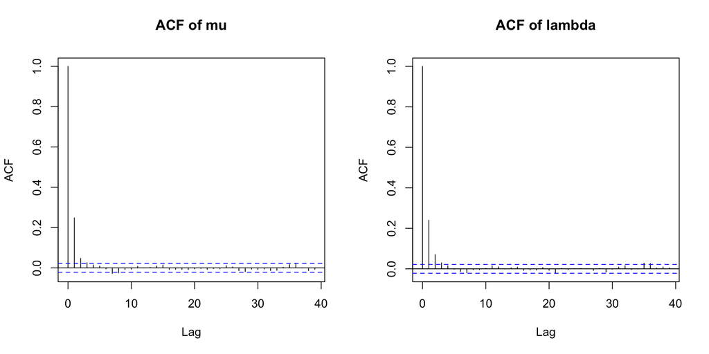

```r
par(mfrow = c(1, 2))
acf(mu_samp, main = "ACF of mu")
acf(lambda_samp, main = "ACF of lambda")
```

```r
par(mfrow = c(1, 1))
```

## MCMC - Gibbs sampler: HW5 Problem 3, cont’d

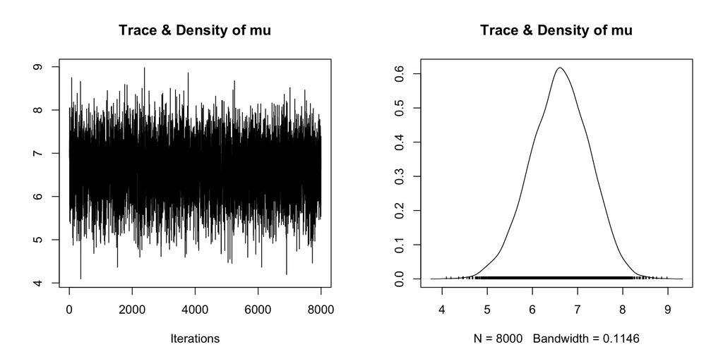

```r
plot(mu_mcmc, main = "Trace & Density of mu")
```

## MCMC - Gibbs sampler: HW5 Problem 3, cont’d

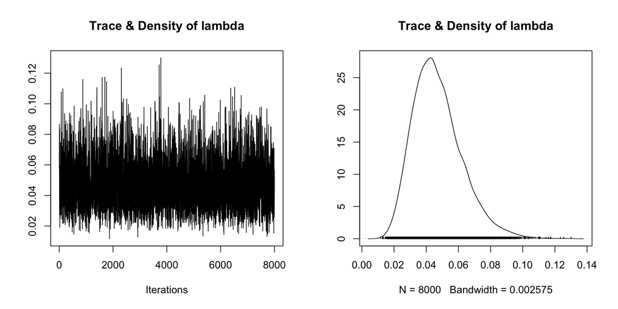

```r
plot(lambda_mcmc, main = "Trace & Density of lambda")
```

## MCMC - Gibbs sampler: HW5 Problem 3, cont’d

Evaluate the marginal posterior density $p(\lambda \mid \mathbf{x})$ analytically up to a normalizing constant and overlay this density on your plot.

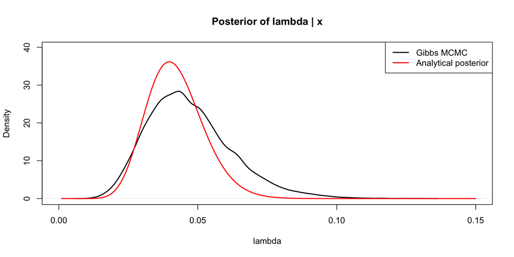

## MCMC - Gibbs sampler & MH(package(coda))

- You can technically wrap any numeric vector or matrix(`object` here) in `mcmc_obj <- mcmc(object)` , even if it isn’t a “real” MCMC sequence. However - and this is key - doing so doesn’t make it an MCMC chain in a statistical sense. It just labels it as one so that functions like `plot()`, `acf()`, and `effectiveSize()` can run without error.

| Function | Purpose |
| --- | --- |
| `effectiveSize(mcmc_obj)` | Computes **Effective Sample Size (ESS)** — measures chain independence. |
| `gelman.diag(mcmc.list_obj)` | **Gelman–Rubin diagnostic** for checking convergence across multiple chains. |
| `geweke.diag(mcmc_obj)` | **Geweke diagnostic** for within-chain convergence (compares early vs. late samples). |
| `heidel.diag(mcmc_obj)` | **Heidelberger–Welch test** for stationarity and convergence. |
| `raftery.diag(mcmc_obj)` | **Raftery–Lewis diagnostic** estimating chain length needed for precision. |

## MCMC - Metropolis-Hastings Algorithm

Let’s recap of Key Concepts

- **Step 1:** Propose a candidate sample from the proposal (transition) distribution
  $$g(x_{t+1} \mid x_t)$$
  For example, if the proposal is Normal,
  $$g(x_{t+1} \mid x_t) = \mathcal{N}(x_t, \sigma^2)$$
- **Step 2:** Accept the proposed value with probability
  $$A(x_t \rightarrow x_{t+1})$$

Detail Balance Condition to reach stationary: $\quad p(a) T(a \rightarrow b)=p(b) T(b \rightarrow a), \quad \forall a, b$

$$\begin{aligned}
\frac{f(a)}{NC} g(b \mid a) A(a \rightarrow b)=\frac{f(b)}{NC } g(a \mid b) A(b \rightarrow a)
\end{aligned}$$

## MCMC - Metropolis-Hastings Algorithm

$$\begin{aligned}
\frac{f(a)}{NC} g(b \mid a) A(a \rightarrow b)=\frac{f(b)}{NC } g(a \mid b) A(b \rightarrow a)
\end{aligned}$$
Rewrite the balance condition:

$$\frac{A(a \rightarrow b)}{A(b \rightarrow a)}=\underbrace{\frac{f(b)}{f(a)}}_{r_f} \times \underbrace{\frac{g(a \mid b)}{g(b \mid a)}}_{r_g}$$

- **Scenario 1**: $r_f r_g<1, A(a \rightarrow b)=r_f r_g, A(b \rightarrow a)=1$
- **Scenario 1**: $r_f r_g>1, A(a \rightarrow b)= 1, A(b \rightarrow a)=\frac{1}{r_f r_g}$

So $A(a \rightarrow b)=\operatorname{min}\left(r_f r_g, 1\right)$

## MCMC - Metropolis-Hastings Algorithm - Intuition

Let’s assume the distribution is symmetric

$$\frac{A(a \rightarrow b)}{A(b \rightarrow a)}=\underbrace{\frac{f(b)}{f(a)}}_{r_f} \times \underbrace{\frac{g(a \mid b)}{g(b \mid a)}}_{r_g} = \underbrace{\frac{f(b)}{f(a)}}_{r_f} = \frac{p(b)}{p(a)} = \frac{p\left(\theta^* \mid y\right)}{p\left(\theta^{(t-1)} \mid y\right)} = r$$

$A(a \rightarrow b)=\operatorname{min}\left(1, \frac{f(b)}{f(a)}\right) =\operatorname{min}\left(1, \frac{p(b)}{p(a)}\right) = \operatorname{min}\left(1, \frac{p\left(\theta^* \mid y\right)}{p\left(\theta^{(t-1)} \mid y\right)}=r\right)$

- If $r>1$:
  - Intuition: Since $\theta^{(t-1)}$ is already in our set, we should include $\theta^*$ as it has a higher probability than $\theta^{(t-1)}$.
  - Procedure: Accept $\theta^*$ into our set, i.e. set $\theta^{(s)}=\theta^*$.
- If $r<1$ :
  - Intuition: The relative frequency of $\theta$-values in our set equal to $\theta^*$ compared to those equal to $\theta^{(t-1)}$ should be $p\left(\theta^* \mid y\right) / p\left(\theta^{(t-1)} \mid y\right)=r$. This means that for every instance of $\theta^{(t-1)}$, we should have only a “fraction” of an instance of a $\theta^*$ value.
  - Procedure: Set $\theta^{(t)}$ equal to either $\theta^*$ or $\theta^{(t-1)}$, with probability $r$ and $1-r$ respectively.

## MCMC - Metropolis-Hastings Algorithm

Consider the file `school1.` dat which contains data on the amount of times students at a high school spent on studying or homework during an exam period. Suppose we fit the following model:

$$\begin{aligned}
Y_i & \sim \mathcal{N}\left(\mu, \sigma^2\right), \quad i=1, \ldots, n \\
\mu & \sim \mathcal{N}\left(\mu_0, \tau_0^2\right)
\end{aligned}$$

with $\mu_0=5, \tau_0^2=0.5$. Let us fix $\sigma^2=1$. Implement a Metropolis-Hastings:

```r
library(coda)

# Read data
y <- scan(url("https://raw.githubusercontent.com/jkstatai/Rice_Fa26_STAT_425/main/docs/Data/school1.dat"))
n <- length(y)

# Known hyperparameters
mu0 <- 5
tau0_sq <- 0.5
sigma_sq <- 1

# Log-posterior: log p(mu | y) ∝ log p(y | mu) + log p(mu)
log_post <- function(mu, y, mu0, tau0_sq, sigma_sq) {
  log_lik <- sum(dnorm(y, mean = mu, sd = sqrt(sigma_sq), log = TRUE))
  log_prior <- dnorm(mu, mean = mu0, sd = sqrt(tau0_sq), log = TRUE)
  log_lik + log_prior
}
```

## MCMC - Metropolis-Hastings Algorithm, cont’d

- A proposal function for $\mu$ centered at the previously sampled value.
- My proposal $\mu^* \sim q\left(\mu^* \mid \mu^{(0)}\right)=N\left(\mu^{(0)}, \sigma_p^2\right)$, where we can set $\mu^{(0)} = \bar{y}$

```r
mean(y)
```

```
[1] 9.464
```

- $\mu^*=\mu^{(t-1)}+\varepsilon, \quad \varepsilon \sim N\left(0, \sigma_p^2\right)$ Hence, $q\left(\mu^* \mid \mu^{(t-1)}\right)=N\left(\mu^{(t-1)}, \sigma_p^2\right)$

```r
# Metropolis–Hastings sampler (Random-Walk proposal)
mh_sampler <- function(sigma_p, n_iter = 5000, burn_in = 1000) {
  mu <- numeric(n_iter)
  mu[1] <- mean(y)

  for (t in 2:n_iter) {
    mu_prop <- rnorm(1, mean = mu[t - 1], sd = sigma_p)
    log_r <- log_post(mu_prop, y, mu0, tau0_sq, sigma_sq) -
             log_post(mu[t - 1], y, mu0, tau0_sq, sigma_sq)
    if (log(runif(1)) < log_r) {
      mu[t] <- mu_prop
    } else {
      mu[t] <- mu[t - 1]
    }
  }

  # Drop burn-in and return MCMC object
  chain <- mcmc(mu[(burn_in + 1):n_iter])
  return(chain)
}
```

## MCMC - Metropolis-Hastings Algorithm, cont’d

```r
# Run chain with sigma_p = 0.5
set.seed(425)
chain_small <- mh_sampler(sigma_p = 0.5)

# Summaries and plots
summary(chain_small)
```

```
Iterations = 1:4000
Thinning interval = 1
Number of chains = 1
Sample size per chain = 4000

1. Empirical mean and standard deviation for each variable,
   plus standard error of the mean:

          Mean             SD       Naive SE Time-series SE
      9.132470       0.193392       0.003058       0.006434

2. Quantiles for each variable:

 2.5%   25%   50%   75% 97.5%
8.768 9.002 9.133 9.264 9.505
```

## MCMC - Metropolis-Hastings Algorithm, contd)

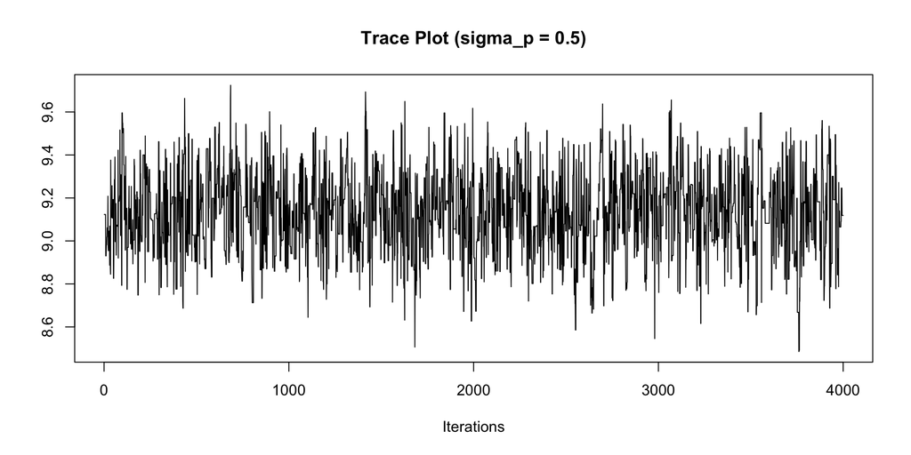

```r
traceplot(chain_small, main = "Trace Plot (sigma_p = 0.5)")
```

## MCMC - Metropolis-Hastings Algorithm, contd)

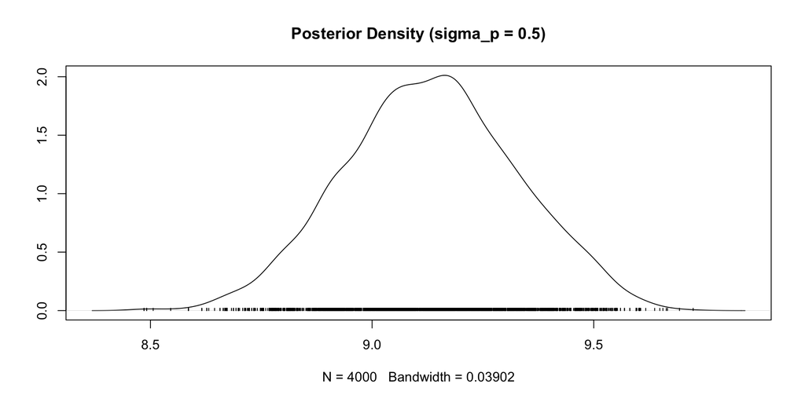

```r
densplot(chain_small, main = "Posterior Density (sigma_p = 0.5)")
```

## MCMC - Metropolis-Hastings Algorithm, cont’d

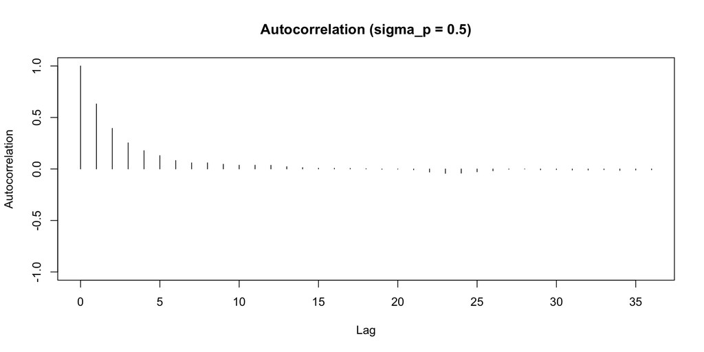

```r
autocorr.plot(chain_small, main = "Autocorrelation (sigma_p = 0.5)")
```

## MCMC - Metropolis-Hastings Algorithm, cont’d

(b) Provide a trace plot and a plot of the histogram and/or kernel density estimate for each chain.

> To answer this, you can run the following code and then compare the plots:

```r
set.seed(123)
chain1 <- mh_sampler(sigma_p = 0.5)
set.seed(456)
chain2 <- mh_sampler(sigma_p = 0.5)
set.seed(789)
chain3 <- mh_sampler(sigma_p = 0.5)
```

- `summary()`,`autocorr.plot()`, `densplot()`
- I have demonstrated the case when $\sigma_p=0.5$. Don’t forget to try $\sigma_p=2$ !

## MCMC - Metropolis-Hastings Algorithm, cont’d

(c) After removing an appropriate burn-in, evaluate the acceptance rate and the autocorrelation for varying lags. Which value of $\sigma_p$ provides a better choice for the proposal function?

```r
# Acceptance rate function
acceptance_rate <- function(chain) {
  draws <- as.numeric(chain)
  mean(diff(draws) != 0)
}
acceptance_rate(chain_small)
```

```
[1] 0.4211053
```

## MCMC - Gibbs sampler & MH(package(coda))

- You can technically wrap any numeric vector or matrix(`object` here) in `mcmc_obj <- mcmc(object)` , even if it isn’t a “real” MCMC sequence. However - and this is key - doing so doesn’t make it an MCMC chain in a statistical sense. It just labels it as one so that functions like `plot()`, `acf()`, and `effectiveSize()` can run without error.

| Function | Purpose |
| --- | --- |
| `effectiveSize(mcmc_obj)` | Computes **Effective Sample Size (ESS)** — measures chain independence. |
| `gelman.diag(mcmc.list_obj)` | **Gelman–Rubin diagnostic** for checking convergence across multiple chains. |
| `geweke.diag(mcmc_obj)` | **Geweke diagnostic** for within-chain convergence (compares early vs. late samples). |
| `heidel.diag(mcmc_obj)` | **Heidelberger–Welch test** for stationarity and convergence. |
| `raftery.diag(mcmc_obj)` | **Raftery–Lewis diagnostic** estimating chain length needed for precision. |

## Finally

[figure not shown]

## Resources

- [*An Introduction to Bayesian Reasoning and Methods* by Kevin Davis](https://peterhoff.io/book/)
- [*A First Course in Bayesian Statistical Methods (school1.dat is from here)* by Dr. Peter Hoff](https://peterhoff.io/book/)
- [Ritvik Kharkar](https://www.linkedin.com/in/ritvik-kharkar/)

# Thank you!

Have a great rest of your day!